# Module 67

#### Contrast SVE:

Signed variance explained (SVE) provides an indication of how similar a set of fold changes are to a gene module’s weight vector. An SVE value of 0.3, for example, indicates that 30% of the variance explained by the entire module set is accounted for by the module in question. Shown here are the SVE values for this module across a compendium of fold changes (contrasts). Extreme SVE values (e.g., > 0.05) indicate that those contrasts specifically induce (orange dots) or specifically repress (blue dots) this module. Examining the experimental conditions being compared in such contrasts (see tables below the figure) may provide insight into the gene module’s function.

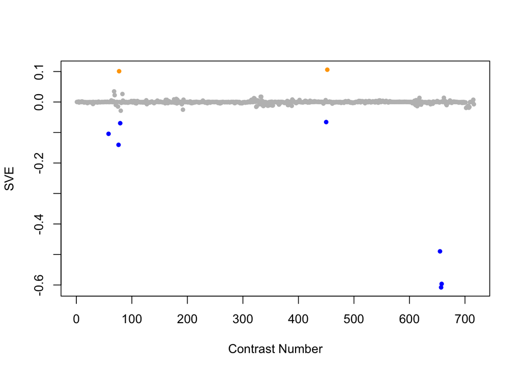

Positive SVE Contrasts:

|  | Contrast.Num | SVE | GEO.GSE | Cond.1 | Cond.2 | Mutation |
| --- | --- | --- | --- | --- | --- | --- |
| GSE25633.s1t1.vs.s2t1 | 452 | 0.11 | GSE25633 | WT#1 | daf-19,daf-12#1 | daf-19;daf-12 |
| GSE8004.s3t2.vs.s1t2 | 77 | 0.10 | GSE8004 | Larval Pan-neural, biological rep 1 of set 2 | Larval A-class, biological rep 1 of set 3 |  |
| GSE8462.s2t1.vs.s1t1 | 68 | 0.03 | GSE8462 | 0 hr Reference, biological rep 1 | 0 hr muscle, biological rep 1 |  |
| GSE6563.s1t1.vs.s0t1 | 83 | 0.03 | GSE6563 | daf19(m86)_daf12(sa204) replicate 1 | daf19(WT)_daf12(sa204) replicate 1 | daf-19 |
| GSE8462.s2t2.vs.s1t2 | 69 | 0.02 | GSE8462 | 24 hr Reference, biological rep 1 | 24 hr muscle, biological rep 1 |  |

Negative SVE Contrasts:

|  | Contrast.Num | SVE | GEO.GSE | Cond.1 | Cond.2 | Mutation |
| --- | --- | --- | --- | --- | --- | --- |
| GSE16050.s1t2.vs.s1t1 | 657 | -0.61 | GSE16050 | MT_GFPm_rep1 | MT_GFPp_rep1 |  |
| GSE16050.s0t2.vs.s0t1 | 658 | -0.60 | GSE16050 | WT_GFPm_rep1 | WT_GFPp_rep1 |  |
| GSE16050.s1t2.vs.s0t2 | 655 | -0.49 | GSE16050 | MT_GFPm_rep1 | WT_GFPm_rep1 |  |
| GSE8004.s2t1.vs.s3t1 | 76 | -0.14 | GSE8004 | Embryonic Reference, biological rep 1 of set 1 | Embryonic Pan-neural, biological rep 1 of set 1 |  |
| GSE9485.s2t1.vs.s1t1 | 58 | -0.10 | GSE9485 | Larval Reference, biological rep 1 | Larval Pan-neural, biological rep 1 |  |
| GSE8004.s2t2.vs.s3t2 | 79 | -0.07 | GSE8004 | Larval Reference, biological rep 1 of set 1 | Larval Pan-neural, biological rep 1 of set 2 |  |
| GSE25633.s2t1.vs.s3t1 | 450 | -0.07 | GSE25633 | daf-19,daf-12#1 | daf-12#1 | daf-19 |

$~$

#### Contrast SVE, Up-Regulated Genes Only:

Calculating SVE for up-regulated and down-regulated genes separately may be more informative in many cases than projecting the up- and down- gene sets together. This is due to the fact that the weight distribution of many modules is highly skewed, indicating that only one of the hemi-modules may be biologically meaningful (i.e., a set of genes are strongly correlated by only a few genes (or none) are strongly anti-correlated to that set.)

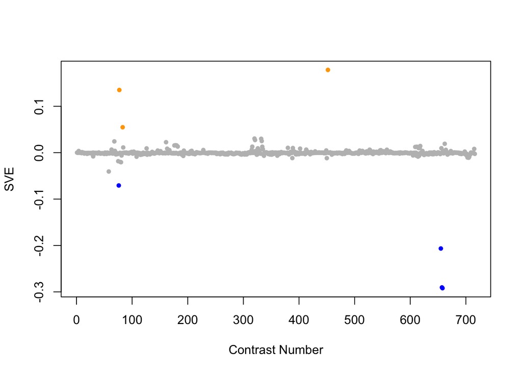

Positive SVE Contrasts:

|  | Contrast.Num | SVE | GEO.GSE | Cond.1 | Cond.2 | Mutation |
| --- | --- | --- | --- | --- | --- | --- |
| GSE25633.s1t1.vs.s2t1 | 452 | 0.18 | GSE25633 | WT#1 | daf-19,daf-12#1 | daf-19;daf-12 |
| GSE8004.s3t2.vs.s1t2 | 77 | 0.14 | GSE8004 | Larval Pan-neural, biological rep 1 of set 2 | Larval A-class, biological rep 1 of set 3 |  |
| GSE6563.s1t1.vs.s0t1 | 83 | 0.05 | GSE6563 | daf19(m86)_daf12(sa204) replicate 1 | daf19(WT)_daf12(sa204) replicate 1 | daf-19 |
| GSE38997.s2t3.vs.s1t3 | 320 | 0.03 | GSE38997 | experiment 1 EtBr-exposed samples at 48 h 1e48 | experiment 1 control samples at 48 h 1c48 |  |
| GSE38997.s2t2.vs.s1t2 | 332 | 0.03 | GSE38997 | experiment 4 EtBr-exposed samples at 24 h 4e24 | experiment 4 control samples at 24 h 4c24 |  |

Negative SVE Contrasts:

|  | Contrast.Num | SVE | GEO.GSE | Cond.1 | Cond.2 | Mutation |
| --- | --- | --- | --- | --- | --- | --- |
| GSE16050.s0t2.vs.s0t1 | 658 | -0.29 | GSE16050 | WT_GFPm_rep1 | WT_GFPp_rep1 |  |
| GSE16050.s1t2.vs.s1t1 | 657 | -0.29 | GSE16050 | MT_GFPm_rep1 | MT_GFPp_rep1 |  |
| GSE16050.s1t2.vs.s0t2 | 655 | -0.21 | GSE16050 | MT_GFPm_rep1 | WT_GFPm_rep1 |  |
| GSE8004.s2t1.vs.s3t1 | 76 | -0.07 | GSE8004 | Embryonic Reference, biological rep 1 of set 1 | Embryonic Pan-neural, biological rep 1 of set 1 |  |
| GSE9485.s2t1.vs.s1t1 | 58 | -0.04 | GSE9485 | Larval Reference, biological rep 1 | Larval Pan-neural, biological rep 1 |  |

$~$

#### Contrast SVE, Down-Regulated Genes Only:

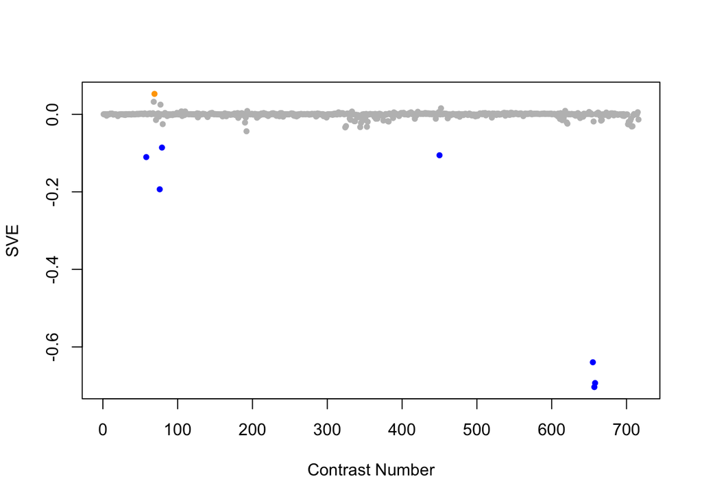

Positive SVE Contrasts:

|  | Contrast.Num | SVE | GEO.GSE | Cond.1 | Cond.2 | Mutation |
| --- | --- | --- | --- | --- | --- | --- |
| GSE8462.s2t2.vs.s1t2 | 69 | 0.05 | GSE8462 | 24 hr Reference, biological rep 1 | 24 hr muscle, biological rep 1 |  |
| GSE8462.s2t1.vs.s1t1 | 68 | 0.03 | GSE8462 | 0 hr Reference, biological rep 1 | 0 hr muscle, biological rep 1 |  |
| GSE8004.s3t2.vs.s1t2 | 77 | 0.02 | GSE8004 | Larval Pan-neural, biological rep 1 of set 2 | Larval A-class, biological rep 1 of set 3 |  |
| GSE25633.s1t1.vs.s2t1 | 452 | 0.02 | GSE25633 | WT#1 | daf-19,daf-12#1 | daf-19;daf-12 |
| GSE21591.s1t1.vs.s2t1 | 618 | 0.01 | GSE21591 | N2_aFLAG_1 | Input_1 |  |

Negative SVE Contrasts:

|  | Contrast.Num | SVE | GEO.GSE | Cond.1 | Cond.2 | Mutation |
| --- | --- | --- | --- | --- | --- | --- |
| GSE16050.s1t2.vs.s1t1 | 657 | -0.70 | GSE16050 | MT_GFPm_rep1 | MT_GFPp_rep1 |  |
| GSE16050.s0t2.vs.s0t1 | 658 | -0.69 | GSE16050 | WT_GFPm_rep1 | WT_GFPp_rep1 |  |
| GSE16050.s1t2.vs.s0t2 | 655 | -0.64 | GSE16050 | MT_GFPm_rep1 | WT_GFPm_rep1 |  |
| GSE8004.s2t1.vs.s3t1 | 76 | -0.19 | GSE8004 | Embryonic Reference, biological rep 1 of set 1 | Embryonic Pan-neural, biological rep 1 of set 1 |  |
| GSE9485.s2t1.vs.s1t1 | 58 | -0.11 | GSE9485 | Larval Reference, biological rep 1 | Larval Pan-neural, biological rep 1 |  |
| GSE25633.s2t1.vs.s3t1 | 450 | -0.11 | GSE25633 | daf-19,daf-12#1 | daf-12#1 | daf-19 |
| GSE8004.s2t2.vs.s3t2 | 79 | -0.09 | GSE8004 | Larval Reference, biological rep 1 of set 1 | Larval Pan-neural, biological rep 1 of set 2 |  |

$~$

$~$

#### GO Term Enrichment:

This analysis tests each hemi-module for enrichment of specific GO terms. Only gene-level annotations (e.g., as would be found on the gene’s page in Wormbase) are tested - the hierarchical structure of the GO ontology is not taken into account.

*Note: At least the top two most enriched terms from each GO domain (BP/MF/CC) are shown, even when not statistically significant.*

##### Enriched GO terms: Hemi-module A

| ID | GO.Term | GO Domain | Raw p-value | Adj p-value |
| --- | --- | --- | --- | --- |
| [GO_1905515](http://amigo.geneontology.org/amigo/term/GO:1905515) | non-motile cilium assembly | BP | 5.61e-50 | 2.04e-46 |
| [GO_0060271](http://amigo.geneontology.org/amigo/term/GO:0060271) | cilium assembly | BP | 3.54e-49 | 6.45e-46 |
| [GO_0006935](http://amigo.geneontology.org/amigo/term/GO:0006935) | chemotaxis | BP | 9.26e-26 | 1.12e-22 |
| [GO_0030030](http://amigo.geneontology.org/amigo/term/GO:0030030) | cell projection organization | BP | 1.04e-24 | 9.51e-22 |
| [GO_0042073](http://amigo.geneontology.org/amigo/term/GO:0042073) | intraciliary transport | BP | 2.32e-24 | 1.69e-21 |
| [GO_0035721](http://amigo.geneontology.org/amigo/term/GO:0035721) | intraciliary retrograde transport | BP | 3.41e-15 | 2.07e-12 |
| [GO_1904491](http://amigo.geneontology.org/amigo/term/GO:1904491) | protein localization to ciliary transition zone | BP | 1.23e-12 | 6.41e-10 |
| [GO_0007635](http://amigo.geneontology.org/amigo/term/GO:0007635) | chemosensory behavior | BP | 3.24e-09 | 1.48e-06 |
| [GO_0008104](http://amigo.geneontology.org/amigo/term/GO:0008104) | protein localization | BP | 1.25e-08 | 5.05e-06 |
| [GO_0097500](http://amigo.geneontology.org/amigo/term/GO:0097500) | receptor localization to non-motile cilium | BP | 1.84e-08 | 6.70e-06 |
| [GO_0007608](http://amigo.geneontology.org/amigo/term/GO:0007608) | sensory perception of smell | BP | 9.70e-08 | 3.21e-05 |
| [GO_0007188](http://amigo.geneontology.org/amigo/term/GO:0007188) | adenylate cyclase-modulating G protein-coupled receptor signaling pathway | BP | 2.05e-07 | 6.23e-05 |
| [GO_0035177](http://amigo.geneontology.org/amigo/term/GO:0035177) | larval foraging behavior | BP | 3.84e-07 | 1.08e-04 |
| [GO_0050896](http://amigo.geneontology.org/amigo/term/GO:0050896) | response to stimulus | BP | 1.51e-06 | 3.93e-04 |
| [GO_0061512](http://amigo.geneontology.org/amigo/term/GO:0061512) | protein localization to cilium | BP | 1.88e-06 | 4.57e-04 |
| [GO_0043053](http://amigo.geneontology.org/amigo/term/GO:0043053) | dauer entry | BP | 2.29e-06 | 5.21e-04 |
| [GO_0009190](http://amigo.geneontology.org/amigo/term/GO:0009190) | cyclic nucleotide biosynthetic process | BP | 3.56e-06 | 7.62e-04 |
| [GO_0040040](http://amigo.geneontology.org/amigo/term/GO:0040040) | thermosensory behavior | BP | 1.03e-05 | 2.09e-03 |
| [GO_0006182](http://amigo.geneontology.org/amigo/term/GO:0006182) | cGMP biosynthetic process | BP | 1.40e-05 | 2.68e-03 |
| [GO_0035735](http://amigo.geneontology.org/amigo/term/GO:0035735) | intraciliary transport involved in cilium assembly | BP | 1.55e-05 | 2.69e-03 |
| [GO_1902017](http://amigo.geneontology.org/amigo/term/GO:1902017) | regulation of cilium assembly | BP | 1.55e-05 | 2.69e-03 |
| [GO_0006972](http://amigo.geneontology.org/amigo/term/GO:0006972) | hyperosmotic response | BP | 2.15e-05 | 3.55e-03 |
| [GO_0007165](http://amigo.geneontology.org/amigo/term/GO:0007165) | signal transduction | BP | 3.22e-05 | 5.10e-03 |
| [GO_0043052](http://amigo.geneontology.org/amigo/term/GO:0043052) | thermotaxis | BP | 1.10e-04 | 1.67e-02 |
| [GO_0042048](http://amigo.geneontology.org/amigo/term/GO:0042048) | olfactory behavior | BP | 1.29e-04 | 1.88e-02 |
| [GO_0035720](http://amigo.geneontology.org/amigo/term/GO:0035720) | intraciliary anterograde transport | BP | 1.49e-04 | 2.09e-02 |
| [GO_0007186](http://amigo.geneontology.org/amigo/term/GO:0007186) | G protein-coupled receptor signaling pathway | BP | 2.90e-04 | 3.92e-02 |
| [GO_0007168](http://amigo.geneontology.org/amigo/term/GO:0007168) | receptor guanylyl cyclase signaling pathway | BP | 3.34e-04 | 4.34e-02 |
| [GO_0035556](http://amigo.geneontology.org/amigo/term/GO:0035556) | intracellular signal transduction | BP | 3.85e-04 | 4.83e-02 |
| [GO_0046907](http://amigo.geneontology.org/amigo/term/GO:0046907) | intracellular transport | BP | 5.04e-04 | 6.11e-02 |

[output cut: 53 more lines]

##### Enriched GO terms: Hemi-module B

| ID | GO.Term | GO Domain | Raw p-value | Adj p-value |
| --- | --- | --- | --- | --- |
| [GO_0035025](http://amigo.geneontology.org/amigo/term/GO:0035025) | positive regulation of Rho protein signal transduction | BP | 6.44e-05 | 2.35e-01 |
| [GO_0006683](http://amigo.geneontology.org/amigo/term/GO:0006683) | galactosylceramide catabolic process | BP | 3.32e-03 | 1.00e+00 |
| [GO_0004181](http://amigo.geneontology.org/amigo/term/GO:0004181) | metallocarboxypeptidase activity | MF | 1.10e-03 | 9.70e-01 |
| [GO_0004180](http://amigo.geneontology.org/amigo/term/GO:0004180) | carboxypeptidase activity | MF | 2.17e-03 | 9.70e-01 |
| [GO_0002102](http://amigo.geneontology.org/amigo/term/GO:0002102) | podosome | CC | 3.32e-03 | 1.00e+00 |
| [GO_0036194](http://amigo.geneontology.org/amigo/term/GO:0036194) | muscle cell projection | CC | 3.32e-03 | 1.00e+00 |

$~$

$~$

#### Tissue Enrichment:

This analysis tests each hemi-module for enrichment of genes associated with anatomy terms. Negative enrichment scores indicate fewer hemi-module genes than expected by random chance were associated with the anatomy term in question.

##### Enriched tissues: Hemi-module A

| ID | Anatomy.Term | Definition | Raw p-value | Adj p-value |
| --- | --- | --- | --- | --- |
| [WBbt_0005394](https://wormbase.org/species/all/anatomy_term/WBbt:0005394) | amphid neuron | neuron of the amphid sensillum | 4.23e-44 | 1.03e-40 |
| [WBbt_0006816](https://wormbase.org/species/all/anatomy_term/WBbt:0006816) | ciliated neuron | neuron type, neurons that have ciliated nerve endings. | 1.86e-42 | 2.27e-39 |
| [WBbt_0006753](https://wormbase.org/species/all/anatomy_term/WBbt:0006753) | phasmid neuron | neuron of phasmid sensillum | 1.07e-38 | 8.72e-36 |
| [WBbt_0003885](https://wormbase.org/species/all/anatomy_term/WBbt:0003885) | ASJR | one member of Amphid neurons, single ciliated endings, probably chemo-sensory; project into ring via commissure from ventral ganglion, make diverse synaptic connections in ring neuropil | 9.83e-30 | 5.98e-27 |
| [WBbt_0003886](https://wormbase.org/species/all/anatomy_term/WBbt:0003886) | ASJL | one member of Amphid neurons, single ciliated endings, probably chemo-sensory; project into ring via commissure from ventral ganglion, make diverse synaptic connections in ring neuropil | 2.21e-29 | 1.08e-26 |
| [WBbt_0005759](https://wormbase.org/species/all/anatomy_term/WBbt:0005759) | sensory neuron | neuron that senses external stimuli and transduce them to signals internal to the organism. | 2.72e-28 | 1.10e-25 |
| [WBbt_0005117](https://wormbase.org/species/all/anatomy_term/WBbt:0005117) | inner labial neuron | neuron type, member of a set of 12 neurons of the inner labial sensilla. | 1.58e-22 | 5.48e-20 |
| [WBbt_0003889](https://wormbase.org/species/all/anatomy_term/WBbt:0003889) | ASHR | one member of Amphid neurons, single ciliated endings, probably chemo-sensory; project into ring via commissure from ventral ganglion, make diverse synaptic connections in ring neuropil | 8.89e-21 | 2.70e-18 |
| [WBbt_0003890](https://wormbase.org/species/all/anatomy_term/WBbt:0003890) | ASHL | one member of Amphid neurons, single ciliated endings, probably chemo-sensory; project into ring via commissure from ventral ganglion, make diverse synaptic connections in ring neuropil | 1.15e-20 | 3.10e-18 |
| [WBbt_0003883](https://wormbase.org/species/all/anatomy_term/WBbt:0003883) | ASKR | one member of Amphid neurons, single ciliated endings, probably chemo-sensory; project into ring via commissure from ventral ganglion, make diverse synaptic connections in ring neuropil | 4.40e-20 | 1.07e-17 |
| [WBbt_0003884](https://wormbase.org/species/all/anatomy_term/WBbt:0003884) | ASKL | one member of Amphid neurons, single ciliated endings, probably chemo-sensory; project into ring via commissure from ventral ganglion, make diverse synaptic connections in ring neuropil | 7.28e-20 | 1.61e-17 |
| [WBbt_0003828](https://wormbase.org/species/all/anatomy_term/WBbt:0003828) | AWBR | Amphid wing cells, neurons having ciliated sheet-like sensory endings closely associated with amphid sheath | 9.81e-19 | 1.98e-16 |
| [WBbt_0005659](https://wormbase.org/species/all/anatomy_term/WBbt:0005659) | PHBR | Phasmid neuron, probably chemosensory | 1.06e-18 | 1.98e-16 |
| [WBbt_0004364](https://wormbase.org/species/all/anatomy_term/WBbt:0004364) | PHBL | Phasmid neurons, probably chemosensory | 1.35e-18 | 2.27e-16 |
| [WBbt_0003829](https://wormbase.org/species/all/anatomy_term/WBbt:0003829) | AWBL | Amphid wing cells, neurons having ciliated sheet-like sensory endings closely associated with amphid sheath | 1.40e-18 | 2.27e-16 |
| [WBbt_0003887](https://wormbase.org/species/all/anatomy_term/WBbt:0003887) | ASIR | one member of Amphid neurons, single ciliated endings, probably chemo-sensory; project into ring via commissure from ventral ganglion, make diverse synaptic connections in ring neuropil | 1.64e-18 | 2.35e-16 |
| [WBbt_0003888](https://wormbase.org/species/all/anatomy_term/WBbt:0003888) | ASIL | one member of amphid neurons, single ciliated ending, probably chemo-sensory; project into ring via commissure from ventral ganglion, make diverse synaptic connections in ring neuropil | 1.64e-18 | 2.35e-16 |
| [WBbt_0006801](https://wormbase.org/species/all/anatomy_term/WBbt:0006801) | outer labial neuron | neuron type, set of six neurons in the outer labial sensillum. | 1.86e-18 | 2.51e-16 |
| [WBbt_0004365](https://wormbase.org/species/all/anatomy_term/WBbt:0004365) | PHAR | Phasmid neurons, probably chemosensory | 1.06e-17 | 1.29e-15 |
| [WBbt_0004366](https://wormbase.org/species/all/anatomy_term/WBbt:0004366) | PHAL | Phasmid neurons, probably chemosensory | 1.06e-17 | 1.29e-15 |
| [WBbt_0004431](https://wormbase.org/species/all/anatomy_term/WBbt:0004431) | OLQVR | Quadrant outer labial neuron | 4.01e-17 | 4.44e-15 |
| [WBbt_0004437](https://wormbase.org/species/all/anatomy_term/WBbt:0004437) | OLQVL | Quadrant outer labial neuron | 4.01e-17 | 4.44e-15 |
| [WBbt_0003826](https://wormbase.org/species/all/anatomy_term/WBbt:0003826) | AWCR | Amphid wing cells, neurons having ciliated sheet-like sensory endings closely associated with amphid sheath | 5.91e-17 | 5.99e-15 |
| [WBbt_0003827](https://wormbase.org/species/all/anatomy_term/WBbt:0003827) | AWCL | Amphid wing cells, neurons having ciliated sheet-like sensory endings closely associated with amphid sheath | 5.91e-17 | 5.99e-15 |
| [WBbt_0004438](https://wormbase.org/species/all/anatomy_term/WBbt:0004438) | OLQDR | Quadrant outer labial neuron | 6.96e-17 | 6.52e-15 |
| [WBbt_0004439](https://wormbase.org/species/all/anatomy_term/WBbt:0004439) | OLQDL | Quadrant outer labial neuron | 6.96e-17 | 6.52e-15 |
| [WBbt_0003995](https://wormbase.org/species/all/anatomy_term/WBbt:0003995) | ADLR | Amphid neuron, prob. chemosensory | 9.80e-17 | 8.52e-15 |
| [WBbt_0003997](https://wormbase.org/species/all/anatomy_term/WBbt:0003997) | ADLL | Amphid neuron, prob. chemosensory | 9.80e-17 | 8.52e-15 |
| [WBbt_0004096](https://wormbase.org/species/all/anatomy_term/WBbt:0004096) | PQR | Neuron class of one sensory neuron, basal body, not part of a sensillum, projects into preanal gangion. | 2.11e-14 | 1.77e-12 |
| [WBbt_0003904](https://wormbase.org/species/all/anatomy_term/WBbt:0003904) | ASEL | one member of Amphid neurons, single ciliated endings, probably chemo-sensory; project into ring via commissure from ventral ganglion, make diverse synaptic connections in ring neuropil | 2.34e-14 | 1.90e-12 |

[output cut: 74 more lines]

##### Enriched tissues: Hemi-module B

No significant annotations.

$~$

$~$

#### HOMER promoter motif enrichment:

This analysis tests each hemi-module for enrichment of 108 known *C. elegans* transcription factor binding site motifs (see [108 CE motifs](https://katiepod.github.io//all.worm.motifs.html)) using the HOMER (Hypergeometric Optimization of Motif EnRichment) software (see [PMID:20513432](https://pubmed.ncbi.nlm.nih.gov/20513432)). HOMER was run using default parameters on sequences 1 kb upstream of the transcription start site.

##### Motif enrichment: Hemi-module A

Total target sequences = 377  
Total background sequences = 40905  
* - possible false positive

Rank

Motif

P-value

log P-pvalue

% of Targets

% of Background

STD(Bg STD)

Best Match/Details

Motif File

1

[figure not shown]

1e-62

-1.438e+02

25.99%

2.74%

230.7bp (319.9bp)

mab-3/MA0262.1/Jaspar(0.536)  
[More Information](https://katiepod.github.io/HomerResults/m67_a_hemi_genes.txt.out.1kb/homerResults/motif1.info.html) | [Similar Motifs Found](https://katiepod.github.io/HomerResults/m67_a_hemi_genes.txt.out.1kb/homerResults/motif1.similar.html)

[motif file (matrix)](https://katiepod.github.io/HomerResults/m67_a_hemi_genes.txt.out.1kb/homerResults/motif1.motif)

2

[figure not shown]

1e-12

-2.950e+01

7.96%

1.44%

288.5bp (313.5bp)

POL008.1_DCE_S_I/Jaspar(0.663)  
[More Information](https://katiepod.github.io/HomerResults/m67_a_hemi_genes.txt.out.1kb/homerResults/motif2.info.html) | [Similar Motifs Found](https://katiepod.github.io/HomerResults/m67_a_hemi_genes.txt.out.1kb/homerResults/motif2.similar.html)

[motif file (matrix)](https://katiepod.github.io/HomerResults/m67_a_hemi_genes.txt.out.1kb/homerResults/motif2.motif)

3

[figure not shown]

1e-12

-2.831e+01

5.31%

0.59%

295.1bp (325.3bp)

PL0015.1_hlh-2::hlh-14/Jaspar(0.677)  
[More Information](https://katiepod.github.io/HomerResults/m67_a_hemi_genes.txt.out.1kb/homerResults/motif3.info.html) | [Similar Motifs Found](https://katiepod.github.io/HomerResults/m67_a_hemi_genes.txt.out.1kb/homerResults/motif3.similar.html)

[motif file (matrix)](https://katiepod.github.io/HomerResults/m67_a_hemi_genes.txt.out.1kb/homerResults/motif3.motif)

4 *

[figure not shown]

1e-11

-2.720e+01

3.18%

0.14%

300.4bp (331.1bp)

MF0010.1_Homeobox_class/Jaspar(0.648)  
[More Information](https://katiepod.github.io/HomerResults/m67_a_hemi_genes.txt.out.1kb/homerResults/motif4.info.html) | [Similar Motifs Found](https://katiepod.github.io/HomerResults/m67_a_hemi_genes.txt.out.1kb/homerResults/motif4.similar.html)

[motif file (matrix)](https://katiepod.github.io/HomerResults/m67_a_hemi_genes.txt.out.1kb/homerResults/motif4.motif)

5 *

[figure not shown]

1e-11

-2.627e+01

18.30%

7.37%

253.6bp (315.1bp)

SD0003.1_at_AC_acceptor/Jaspar(0.722)  
[More Information](https://katiepod.github.io/HomerResults/m67_a_hemi_genes.txt.out.1kb/homerResults/motif5.info.html) | [Similar Motifs Found](https://katiepod.github.io/HomerResults/m67_a_hemi_genes.txt.out.1kb/homerResults/motif5.similar.html)

[motif file (matrix)](https://katiepod.github.io/HomerResults/m67_a_hemi_genes.txt.out.1kb/homerResults/motif5.motif)

6 *

[figure not shown]

1e-11

-2.609e+01

10.08%

2.63%

251.0bp (304.4bp)

SD0003.1_at_AC_acceptor/Jaspar(0.778)  
[More Information](https://katiepod.github.io/HomerResults/m67_a_hemi_genes.txt.out.1kb/homerResults/motif6.info.html) | [Similar Motifs Found](https://katiepod.github.io/HomerResults/m67_a_hemi_genes.txt.out.1kb/homerResults/motif6.similar.html)

[motif file (matrix)](https://katiepod.github.io/HomerResults/m67_a_hemi_genes.txt.out.1kb/homerResults/motif6.motif)

7 *

[figure not shown]

1e-11

-2.573e+01

10.88%

3.07%

291.3bp (310.2bp)

pha-4/MA0546.1/Jaspar(0.523)  
[More Information](https://katiepod.github.io/HomerResults/m67_a_hemi_genes.txt.out.1kb/homerResults/motif7.info.html) | [Similar Motifs Found](https://katiepod.github.io/HomerResults/m67_a_hemi_genes.txt.out.1kb/homerResults/motif7.similar.html)

[motif file (matrix)](https://katiepod.github.io/HomerResults/m67_a_hemi_genes.txt.out.1kb/homerResults/motif7.motif)

8 *

[figure not shown]

1e-10

-2.522e+01

7.43%

1.49%

279.5bp (298.7bp)

PL0011.1_hlh-2::hlh-4/Jaspar(0.530)  
[More Information](https://katiepod.github.io/HomerResults/m67_a_hemi_genes.txt.out.1kb/homerResults/motif8.info.html) | [Similar Motifs Found](https://katiepod.github.io/HomerResults/m67_a_hemi_genes.txt.out.1kb/homerResults/motif8.similar.html)

[motif file (matrix)](https://katiepod.github.io/HomerResults/m67_a_hemi_genes.txt.out.1kb/homerResults/motif8.motif)

9 *

[figure not shown]

1e-10

-2.449e+01

6.37%

1.11%

284.8bp (305.5bp)

unc-86/MA0926.1/Jaspar(0.586)  
[More Information](https://katiepod.github.io/HomerResults/m67_a_hemi_genes.txt.out.1kb/homerResults/motif9.info.html) | [Similar Motifs Found](https://katiepod.github.io/HomerResults/m67_a_hemi_genes.txt.out.1kb/homerResults/motif9.similar.html)

[motif file (matrix)](https://katiepod.github.io/HomerResults/m67_a_hemi_genes.txt.out.1kb/homerResults/motif9.motif)

10 *

[figure not shown]

1e-10

-2.407e+01

9.28%

2.43%

296.2bp (291.1bp)

lin-54/MA1450.1/Jaspar(0.655)  
[More Information](https://katiepod.github.io/HomerResults/m67_a_hemi_genes.txt.out.1kb/homerResults/motif10.info.html) | [Similar Motifs Found](https://katiepod.github.io/HomerResults/m67_a_hemi_genes.txt.out.1kb/homerResults/motif10.similar.html)

[motif file (matrix)](https://katiepod.github.io/HomerResults/m67_a_hemi_genes.txt.out.1kb/homerResults/motif10.motif)

11 *

[figure not shown]

1e-10

-2.402e+01

13.26%

4.59%

307.0bp (322.6bp)

unc-30/MA1443.1/Jaspar(0.667)  
[More Information](https://katiepod.github.io/HomerResults/m67_a_hemi_genes.txt.out.1kb/homerResults/motif11.info.html) | [Similar Motifs Found](https://katiepod.github.io/HomerResults/m67_a_hemi_genes.txt.out.1kb/homerResults/motif11.similar.html)

[motif file (matrix)](https://katiepod.github.io/HomerResults/m67_a_hemi_genes.txt.out.1kb/homerResults/motif11.motif)

12 *

[figure not shown]

1e-10

-2.375e+01

26.26%

13.50%

298.7bp (315.4bp)

daf-16/MA1446.1/Jaspar(0.650)  
[More Information](https://katiepod.github.io/HomerResults/m67_a_hemi_genes.txt.out.1kb/homerResults/motif12.info.html) | [Similar Motifs Found](https://katiepod.github.io/HomerResults/m67_a_hemi_genes.txt.out.1kb/homerResults/motif12.similar.html)

[motif file (matrix)](https://katiepod.github.io/HomerResults/m67_a_hemi_genes.txt.out.1kb/homerResults/motif12.motif)

13 *

[figure not shown]

1e-10

-2.368e+01

3.45%

0.25%

238.3bp (319.3bp)

POL012.1_TATA-Box/Jaspar(0.528)  
[More Information](https://katiepod.github.io/HomerResults/m67_a_hemi_genes.txt.out.1kb/homerResults/motif13.info.html) | [Similar Motifs Found](https://katiepod.github.io/HomerResults/m67_a_hemi_genes.txt.out.1kb/homerResults/motif13.similar.html)

[motif file (matrix)](https://katiepod.github.io/HomerResults/m67_a_hemi_genes.txt.out.1kb/homerResults/motif13.motif)

14 *

[figure not shown]

1e-10

-2.357e+01

3.45%

0.25%

323.1bp (328.1bp)

POL008.1_DCE_S_I/Jaspar(0.610)  
[More Information](https://katiepod.github.io/HomerResults/m67_a_hemi_genes.txt.out.1kb/homerResults/motif14.info.html) | [Similar Motifs Found](https://katiepod.github.io/HomerResults/m67_a_hemi_genes.txt.out.1kb/homerResults/motif14.similar.html)

[motif file (matrix)](https://katiepod.github.io/HomerResults/m67_a_hemi_genes.txt.out.1kb/homerResults/motif14.motif)

15 *

[figure not shown]

1e-10

-2.334e+01

14.32%

5.32%

279.7bp (318.5bp)

POL008.1_DCE_S_I/Jaspar(0.569)  
[More Information](https://katiepod.github.io/HomerResults/m67_a_hemi_genes.txt.out.1kb/homerResults/motif15.info.html) | [Similar Motifs Found](https://katiepod.github.io/HomerResults/m67_a_hemi_genes.txt.out.1kb/homerResults/motif15.similar.html)

[motif file (matrix)](https://katiepod.github.io/HomerResults/m67_a_hemi_genes.txt.out.1kb/homerResults/motif15.motif)

16 *

[figure not shown]

1e-10

-2.312e+01

6.37%

1.19%

260.0bp (324.0bp)

POL010.1_DCE_S_III/Jaspar(0.556)  
[More Information](https://katiepod.github.io/HomerResults/m67_a_hemi_genes.txt.out.1kb/homerResults/motif16.info.html) | [Similar Motifs Found](https://katiepod.github.io/HomerResults/m67_a_hemi_genes.txt.out.1kb/homerResults/motif16.similar.html)

[motif file (matrix)](https://katiepod.github.io/HomerResults/m67_a_hemi_genes.txt.out.1kb/homerResults/motif16.motif)

17 *

[figure not shown]

1e-9

-2.234e+01

4.51%

0.57%

273.8bp (290.8bp)

zfh-2/MA0928.1/Jaspar(0.628)  
[More Information](https://katiepod.github.io/HomerResults/m67_a_hemi_genes.txt.out.1kb/homerResults/motif17.info.html) | [Similar Motifs Found](https://katiepod.github.io/HomerResults/m67_a_hemi_genes.txt.out.1kb/homerResults/motif17.similar.html)

[motif file (matrix)](https://katiepod.github.io/HomerResults/m67_a_hemi_genes.txt.out.1kb/homerResults/motif17.motif)

18 *

[figure not shown]

1e-9

-2.173e+01

7.43%

1.75%

235.1bp (301.7bp)

blmp-1/MA0537.1/Jaspar(0.677)  
[More Information](https://katiepod.github.io/HomerResults/m67_a_hemi_genes.txt.out.1kb/homerResults/motif18.info.html) | [Similar Motifs Found](https://katiepod.github.io/HomerResults/m67_a_hemi_genes.txt.out.1kb/homerResults/motif18.similar.html)

[motif file (matrix)](https://katiepod.github.io/HomerResults/m67_a_hemi_genes.txt.out.1kb/homerResults/motif18.motif)

19 *

[figure not shown]

1e-9

-2.136e+01

18.30%

8.27%

299.2bp (309.3bp)

unc-86/MA0926.1/Jaspar(0.661)  
[More Information](https://katiepod.github.io/HomerResults/m67_a_hemi_genes.txt.out.1kb/homerResults/motif19.info.html) | [Similar Motifs Found](https://katiepod.github.io/HomerResults/m67_a_hemi_genes.txt.out.1kb/homerResults/motif19.similar.html)

[motif file (matrix)](https://katiepod.github.io/HomerResults/m67_a_hemi_genes.txt.out.1kb/homerResults/motif19.motif)

20 *

[figure not shown]

1e-8

-1.991e+01

2.65%

0.17%

337.9bp (260.4bp)

blmp-1/MA0537.1/Jaspar(0.583)  
[More Information](https://katiepod.github.io/HomerResults/m67_a_hemi_genes.txt.out.1kb/homerResults/motif20.info.html) | [Similar Motifs Found](https://katiepod.github.io/HomerResults/m67_a_hemi_genes.txt.out.1kb/homerResults/motif20.similar.html)

[motif file (matrix)](https://katiepod.github.io/HomerResults/m67_a_hemi_genes.txt.out.1kb/homerResults/motif20.motif)

21 *

[figure not shown]

1e-8

-1.956e+01

3.45%

0.36%

210.0bp (282.7bp)

fkh-9/MA1440.1/Jaspar(0.760)  
[More Information](https://katiepod.github.io/HomerResults/m67_a_hemi_genes.txt.out.1kb/homerResults/motif21.info.html) | [Similar Motifs Found](https://katiepod.github.io/HomerResults/m67_a_hemi_genes.txt.out.1kb/homerResults/motif21.similar.html)

[motif file (matrix)](https://katiepod.github.io/HomerResults/m67_a_hemi_genes.txt.out.1kb/homerResults/motif21.motif)

22 *

[figure not shown]

1e-8

-1.908e+01

13.26%

5.34%

280.1bp (299.7bp)

cebp-1/MA1444.1/Jaspar(0.698)  
[More Information](https://katiepod.github.io/HomerResults/m67_a_hemi_genes.txt.out.1kb/homerResults/motif22.info.html) | [Similar Motifs Found](https://katiepod.github.io/HomerResults/m67_a_hemi_genes.txt.out.1kb/homerResults/motif22.similar.html)

[motif file (matrix)](https://katiepod.github.io/HomerResults/m67_a_hemi_genes.txt.out.1kb/homerResults/motif22.motif)

23 *

[figure not shown]

1e-8

-1.884e+01

9.28%

2.98%

278.2bp (309.1bp)

POL002.1_INR/Jaspar(0.599)  
[More Information](https://katiepod.github.io/HomerResults/m67_a_hemi_genes.txt.out.1kb/homerResults/motif23.info.html) | [Similar Motifs Found](https://katiepod.github.io/HomerResults/m67_a_hemi_genes.txt.out.1kb/homerResults/motif23.similar.html)

[motif file (matrix)](https://katiepod.github.io/HomerResults/m67_a_hemi_genes.txt.out.1kb/homerResults/motif23.motif)

24 *

[figure not shown]

1e-8

-1.875e+01

3.45%

0.39%

280.3bp (304.3bp)

POL008.1_DCE_S_I/Jaspar(0.545)  
[More Information](https://katiepod.github.io/HomerResults/m67_a_hemi_genes.txt.out.1kb/homerResults/motif24.info.html) | [Similar Motifs Found](https://katiepod.github.io/HomerResults/m67_a_hemi_genes.txt.out.1kb/homerResults/motif24.similar.html)

[motif file (matrix)](https://katiepod.github.io/HomerResults/m67_a_hemi_genes.txt.out.1kb/homerResults/motif24.motif)

25 *

[figure not shown]

1e-8

-1.853e+01

6.63%

1.64%

260.4bp (317.3bp)

MF0008.1_MADS_class/Jaspar(0.491)  
[More Information](https://katiepod.github.io/HomerResults/m67_a_hemi_genes.txt.out.1kb/homerResults/motif25.info.html) | [Similar Motifs Found](https://katiepod.github.io/HomerResults/m67_a_hemi_genes.txt.out.1kb/homerResults/motif25.similar.html)

[motif file (matrix)](https://katiepod.github.io/HomerResults/m67_a_hemi_genes.txt.out.1kb/homerResults/motif25.motif)

26 *

[figure not shown]

1e-8

-1.847e+01

2.92%

0.25%

290.9bp (325.6bp)

eor-1/MA0543.1/Jaspar(0.465)  
[More Information](https://katiepod.github.io/HomerResults/m67_a_hemi_genes.txt.out.1kb/homerResults/motif26.info.html) | [Similar Motifs Found](https://katiepod.github.io/HomerResults/m67_a_hemi_genes.txt.out.1kb/homerResults/motif26.similar.html)

[motif file (matrix)](https://katiepod.github.io/HomerResults/m67_a_hemi_genes.txt.out.1kb/homerResults/motif26.motif)

27 *

[figure not shown]

1e-7

-1.827e+01

41.91%

28.27%

272.9bp (312.0bp)

nhr-6/MA1451.1/Jaspar(0.650)  
[More Information](https://katiepod.github.io/HomerResults/m67_a_hemi_genes.txt.out.1kb/homerResults/motif27.info.html) | [Similar Motifs Found](https://katiepod.github.io/HomerResults/m67_a_hemi_genes.txt.out.1kb/homerResults/motif27.similar.html)

[motif file (matrix)](https://katiepod.github.io/HomerResults/m67_a_hemi_genes.txt.out.1kb/homerResults/motif27.motif)

28 *

[figure not shown]

1e-7

-1.765e+01

1.86%

0.07%

247.6bp (305.3bp)

fkh-9/MA1440.1/Jaspar(0.484)  
[More Information](https://katiepod.github.io/HomerResults/m67_a_hemi_genes.txt.out.1kb/homerResults/motif28.info.html) | [Similar Motifs Found](https://katiepod.github.io/HomerResults/m67_a_hemi_genes.txt.out.1kb/homerResults/motif28.similar.html)

[motif file (matrix)](https://katiepod.github.io/HomerResults/m67_a_hemi_genes.txt.out.1kb/homerResults/motif28.motif)

29 *

[figure not shown]

1e-7

-1.762e+01

3.18%

0.35%

295.6bp (328.4bp)

ceh-22/MA0264.1/Jaspar(0.577)  
[More Information](https://katiepod.github.io/HomerResults/m67_a_hemi_genes.txt.out.1kb/homerResults/motif29.info.html) | [Similar Motifs Found](https://katiepod.github.io/HomerResults/m67_a_hemi_genes.txt.out.1kb/homerResults/motif29.similar.html)

[motif file (matrix)](https://katiepod.github.io/HomerResults/m67_a_hemi_genes.txt.out.1kb/homerResults/motif29.motif)

30 *

[figure not shown]

1e-7

-1.638e+01

5.04%

1.09%

266.7bp (324.3bp)

POL003.1_GC-box/Jaspar(0.647)  
[More Information](https://katiepod.github.io/HomerResults/m67_a_hemi_genes.txt.out.1kb/homerResults/motif30.info.html) | [Similar Motifs Found](https://katiepod.github.io/HomerResults/m67_a_hemi_genes.txt.out.1kb/homerResults/motif30.similar.html)

[motif file (matrix)](https://katiepod.github.io/HomerResults/m67_a_hemi_genes.txt.out.1kb/homerResults/motif30.motif)

31 *

[figure not shown]

1e-6

-1.603e+01

3.45%

0.49%

263.3bp (329.3bp)

MF0002.1_bZIP_CREB/G-box-like_subclass/Jaspar(0.505)  
[More Information](https://katiepod.github.io/HomerResults/m67_a_hemi_genes.txt.out.1kb/homerResults/motif31.info.html) | [Similar Motifs Found](https://katiepod.github.io/HomerResults/m67_a_hemi_genes.txt.out.1kb/homerResults/motif31.similar.html)

[motif file (matrix)](https://katiepod.github.io/HomerResults/m67_a_hemi_genes.txt.out.1kb/homerResults/motif31.motif)

32 *

[figure not shown]

1e-6

-1.530e+01

11.67%

4.97%

259.1bp (300.7bp)

blmp-1/MA0537.1/Jaspar(0.536)  
[More Information](https://katiepod.github.io/HomerResults/m67_a_hemi_genes.txt.out.1kb/homerResults/motif32.info.html) | [Similar Motifs Found](https://katiepod.github.io/HomerResults/m67_a_hemi_genes.txt.out.1kb/homerResults/motif32.similar.html)

[motif file (matrix)](https://katiepod.github.io/HomerResults/m67_a_hemi_genes.txt.out.1kb/homerResults/motif32.motif)

33 *

[figure not shown]

1e-6

-1.515e+01

1.86%

0.10%

297.8bp (299.3bp)

POL012.1_TATA-Box/Jaspar(0.650)  
[More Information](https://katiepod.github.io/HomerResults/m67_a_hemi_genes.txt.out.1kb/homerResults/motif33.info.html) | [Similar Motifs Found](https://katiepod.github.io/HomerResults/m67_a_hemi_genes.txt.out.1kb/homerResults/motif33.similar.html)

[motif file (matrix)](https://katiepod.github.io/HomerResults/m67_a_hemi_genes.txt.out.1kb/homerResults/motif33.motif)

34 *

[figure not shown]

1e-6

-1.472e+01

1.86%

0.11%

306.8bp (305.8bp)

POL009.1_DCE_S_II/Jaspar(0.606)  
[More Information](https://katiepod.github.io/HomerResults/m67_a_hemi_genes.txt.out.1kb/homerResults/motif34.info.html) | [Similar Motifs Found](https://katiepod.github.io/HomerResults/m67_a_hemi_genes.txt.out.1kb/homerResults/motif34.similar.html)

[motif file (matrix)](https://katiepod.github.io/HomerResults/m67_a_hemi_genes.txt.out.1kb/homerResults/motif34.motif)

35 *

[figure not shown]

1e-6

-1.455e+01

6.63%

2.04%

266.9bp (292.3bp)

POL004.1_CCAAT-box/Jaspar(0.768)  
[More Information](https://katiepod.github.io/HomerResults/m67_a_hemi_genes.txt.out.1kb/homerResults/motif35.info.html) | [Similar Motifs Found](https://katiepod.github.io/HomerResults/m67_a_hemi_genes.txt.out.1kb/homerResults/motif35.similar.html)

[motif file (matrix)](https://katiepod.github.io/HomerResults/m67_a_hemi_genes.txt.out.1kb/homerResults/motif35.motif)

36 *

[figure not shown]

1e-6

-1.414e+01

2.12%

0.18%

316.6bp (339.1bp)

LIN-39(Homeobox)/cElegans.L3-LIN39-ChIP-Seq(modEncode)/Homer(0.535)  
[More Information](https://katiepod.github.io/HomerResults/m67_a_hemi_genes.txt.out.1kb/homerResults/motif36.info.html) | [Similar Motifs Found](https://katiepod.github.io/HomerResults/m67_a_hemi_genes.txt.out.1kb/homerResults/motif36.similar.html)

[motif file (matrix)](https://katiepod.github.io/HomerResults/m67_a_hemi_genes.txt.out.1kb/homerResults/motif36.motif)

37 *

[figure not shown]

1e-6

-1.387e+01

6.90%

2.27%

273.8bp (305.8bp)

lim-7/MA1441.1/Jaspar(0.624)  
[More Information](https://katiepod.github.io/HomerResults/m67_a_hemi_genes.txt.out.1kb/homerResults/motif37.info.html) | [Similar Motifs Found](https://katiepod.github.io/HomerResults/m67_a_hemi_genes.txt.out.1kb/homerResults/motif37.similar.html)

[motif file (matrix)](https://katiepod.github.io/HomerResults/m67_a_hemi_genes.txt.out.1kb/homerResults/motif37.motif)

38 *

[figure not shown]

1e-5

-1.336e+01

3.45%

0.63%

241.0bp (288.9bp)

POL011.1_XCPE1/Jaspar(0.638)  
[More Information](https://katiepod.github.io/HomerResults/m67_a_hemi_genes.txt.out.1kb/homerResults/motif38.info.html) | [Similar Motifs Found](https://katiepod.github.io/HomerResults/m67_a_hemi_genes.txt.out.1kb/homerResults/motif38.similar.html)

[motif file (matrix)](https://katiepod.github.io/HomerResults/m67_a_hemi_genes.txt.out.1kb/homerResults/motif38.motif)

39 *

[figure not shown]

1e-5

-1.240e+01

2.65%

0.39%

313.0bp (305.7bp)

sma-4/MA0925.1/Jaspar(0.565)  
[More Information](https://katiepod.github.io/HomerResults/m67_a_hemi_genes.txt.out.1kb/homerResults/motif39.info.html) | [Similar Motifs Found](https://katiepod.github.io/HomerResults/m67_a_hemi_genes.txt.out.1kb/homerResults/motif39.similar.html)

[motif file (matrix)](https://katiepod.github.io/HomerResults/m67_a_hemi_genes.txt.out.1kb/homerResults/motif39.motif)

40 *

[figure not shown]

1e-4

-1.133e+01

2.12%

0.26%

304.2bp (284.3bp)

sma-4/MA0925.1/Jaspar(0.567)  
[More Information](https://katiepod.github.io/HomerResults/m67_a_hemi_genes.txt.out.1kb/homerResults/motif40.info.html) | [Similar Motifs Found](https://katiepod.github.io/HomerResults/m67_a_hemi_genes.txt.out.1kb/homerResults/motif40.similar.html)

[motif file (matrix)](https://katiepod.github.io/HomerResults/m67_a_hemi_genes.txt.out.1kb/homerResults/motif40.motif)

41 *

[figure not shown]

1e-2

-5.057e+00

3.98%

1.89%

278.1bp (303.9bp)

skn-1/MA0547.1/Jaspar(0.658)  
[More Information](https://katiepod.github.io/HomerResults/m67_a_hemi_genes.txt.out.1kb/homerResults/motif41.info.html) | [Similar Motifs Found](https://katiepod.github.io/HomerResults/m67_a_hemi_genes.txt.out.1kb/homerResults/motif41.similar.html)

[motif file (matrix)](https://katiepod.github.io/HomerResults/m67_a_hemi_genes.txt.out.1kb/homerResults/motif41.motif)

##### Motif enrichment: Hemi-module B

Total target sequences = 45  
Total background sequences = 40124  
* - possible false positive

Rank

Motif

P-value

log P-pvalue

% of Targets

% of Background

STD(Bg STD)

Best Match/Details

Motif File

1 *

[figure not shown]

1e-9

-2.185e+01

15.56%

0.35%

270.0bp (321.1bp)

lin-54/MA1450.1/Jaspar(0.596)  
[More Information](https://katiepod.github.io/HomerResults/m67_b_hemi_genes.txt.out.1kb/homerResults/motif1.info.html) | [Similar Motifs Found](https://katiepod.github.io/HomerResults/m67_b_hemi_genes.txt.out.1kb/homerResults/motif1.similar.html)

[motif file (matrix)](https://katiepod.github.io/HomerResults/m67_b_hemi_genes.txt.out.1kb/homerResults/motif1.motif)

2 *

[figure not shown]

1e-9

-2.138e+01

46.67%

10.21%

308.1bp (309.6bp)

MF0003.1_REL_class/Jaspar(0.516)  
[More Information](https://katiepod.github.io/HomerResults/m67_b_hemi_genes.txt.out.1kb/homerResults/motif2.info.html) | [Similar Motifs Found](https://katiepod.github.io/HomerResults/m67_b_hemi_genes.txt.out.1kb/homerResults/motif2.similar.html)

[motif file (matrix)](https://katiepod.github.io/HomerResults/m67_b_hemi_genes.txt.out.1kb/homerResults/motif2.motif)

3 *

[figure not shown]

1e-8

-2.041e+01

8.89%

0.03%

312.7bp (281.3bp)

atf-7/MA1438.1/Jaspar(0.528)  
[More Information](https://katiepod.github.io/HomerResults/m67_b_hemi_genes.txt.out.1kb/homerResults/motif3.info.html) | [Similar Motifs Found](https://katiepod.github.io/HomerResults/m67_b_hemi_genes.txt.out.1kb/homerResults/motif3.similar.html)

[motif file (matrix)](https://katiepod.github.io/HomerResults/m67_b_hemi_genes.txt.out.1kb/homerResults/motif3.motif)

4 *

[figure not shown]

1e-8

-1.966e+01

17.78%

0.79%

297.2bp (307.5bp)

elt-6/MA1439.1/Jaspar(0.572)  
[More Information](https://katiepod.github.io/HomerResults/m67_b_hemi_genes.txt.out.1kb/homerResults/motif4.info.html) | [Similar Motifs Found](https://katiepod.github.io/HomerResults/m67_b_hemi_genes.txt.out.1kb/homerResults/motif4.similar.html)

[motif file (matrix)](https://katiepod.github.io/HomerResults/m67_b_hemi_genes.txt.out.1kb/homerResults/motif4.motif)

5 *

[figure not shown]

1e-8

-1.883e+01

17.78%

0.89%

393.9bp (316.6bp)

POL009.1_DCE_S_II/Jaspar(0.532)  
[More Information](https://katiepod.github.io/HomerResults/m67_b_hemi_genes.txt.out.1kb/homerResults/motif5.info.html) | [Similar Motifs Found](https://katiepod.github.io/HomerResults/m67_b_hemi_genes.txt.out.1kb/homerResults/motif5.similar.html)

[motif file (matrix)](https://katiepod.github.io/HomerResults/m67_b_hemi_genes.txt.out.1kb/homerResults/motif5.motif)

6 *

[figure not shown]

1e-8

-1.851e+01

33.33%

5.49%

275.5bp (317.7bp)

CES-1(Homeobox)/cElegans-L1-CES1-ChIP-Seq(modEncode)/Homer(0.589)  
[More Information](https://katiepod.github.io/HomerResults/m67_b_hemi_genes.txt.out.1kb/homerResults/motif6.info.html) | [Similar Motifs Found](https://katiepod.github.io/HomerResults/m67_b_hemi_genes.txt.out.1kb/homerResults/motif6.similar.html)

[motif file (matrix)](https://katiepod.github.io/HomerResults/m67_b_hemi_genes.txt.out.1kb/homerResults/motif6.motif)

7 *

[figure not shown]

1e-7

-1.733e+01

37.78%

8.02%

291.7bp (317.0bp)

cebp-1/MA1444.1/Jaspar(0.535)  
[More Information](https://katiepod.github.io/HomerResults/m67_b_hemi_genes.txt.out.1kb/homerResults/motif7.info.html) | [Similar Motifs Found](https://katiepod.github.io/HomerResults/m67_b_hemi_genes.txt.out.1kb/homerResults/motif7.similar.html)

[motif file (matrix)](https://katiepod.github.io/HomerResults/m67_b_hemi_genes.txt.out.1kb/homerResults/motif7.motif)

8 *

[figure not shown]

1e-7

-1.637e+01

28.89%

4.60%

276.2bp (307.9bp)

nhr-6/MA1451.1/Jaspar(0.681)  
[More Information](https://katiepod.github.io/HomerResults/m67_b_hemi_genes.txt.out.1kb/homerResults/motif8.info.html) | [Similar Motifs Found](https://katiepod.github.io/HomerResults/m67_b_hemi_genes.txt.out.1kb/homerResults/motif8.similar.html)

[motif file (matrix)](https://katiepod.github.io/HomerResults/m67_b_hemi_genes.txt.out.1kb/homerResults/motif8.motif)

9 *

[figure not shown]

1e-6

-1.497e+01

13.33%

0.59%

282.6bp (307.8bp)

GEI-11(Myb?)/cElegans-L4-GEI11-ChIP-Seq(modEncode)/Homer(0.474)  
[More Information](https://katiepod.github.io/HomerResults/m67_b_hemi_genes.txt.out.1kb/homerResults/motif9.info.html) | [Similar Motifs Found](https://katiepod.github.io/HomerResults/m67_b_hemi_genes.txt.out.1kb/homerResults/motif9.similar.html)

[motif file (matrix)](https://katiepod.github.io/HomerResults/m67_b_hemi_genes.txt.out.1kb/homerResults/motif9.motif)

10 *

[figure not shown]

1e-6

-1.473e+01

37.78%

9.60%

284.9bp (307.2bp)

lin-54/MA1450.1/Jaspar(0.685)  
[More Information](https://katiepod.github.io/HomerResults/m67_b_hemi_genes.txt.out.1kb/homerResults/motif10.info.html) | [Similar Motifs Found](https://katiepod.github.io/HomerResults/m67_b_hemi_genes.txt.out.1kb/homerResults/motif10.similar.html)

[motif file (matrix)](https://katiepod.github.io/HomerResults/m67_b_hemi_genes.txt.out.1kb/homerResults/motif10.motif)

11 *

[figure not shown]

1e-5

-1.300e+01

8.89%

0.20%

191.5bp (274.4bp)

GEI-11(Myb?)/cElegans-L4-GEI11-ChIP-Seq(modEncode)/Homer(0.639)  
[More Information](https://katiepod.github.io/HomerResults/m67_b_hemi_genes.txt.out.1kb/homerResults/motif11.info.html) | [Similar Motifs Found](https://katiepod.github.io/HomerResults/m67_b_hemi_genes.txt.out.1kb/homerResults/motif11.similar.html)

[motif file (matrix)](https://katiepod.github.io/HomerResults/m67_b_hemi_genes.txt.out.1kb/homerResults/motif11.motif)

12 *

[figure not shown]

1e-5

-1.286e+01

53.33%

21.36%

292.8bp (317.3bp)

zfh-2/MA0928.1/Jaspar(0.572)  
[More Information](https://katiepod.github.io/HomerResults/m67_b_hemi_genes.txt.out.1kb/homerResults/motif12.info.html) | [Similar Motifs Found](https://katiepod.github.io/HomerResults/m67_b_hemi_genes.txt.out.1kb/homerResults/motif12.similar.html)

[motif file (matrix)](https://katiepod.github.io/HomerResults/m67_b_hemi_genes.txt.out.1kb/homerResults/motif12.motif)

13 *

[figure not shown]

1e-5

-1.273e+01

6.67%

0.06%

190.6bp (287.0bp)

POL008.1_DCE_S_I/Jaspar(0.602)  
[More Information](https://katiepod.github.io/HomerResults/m67_b_hemi_genes.txt.out.1kb/homerResults/motif13.info.html) | [Similar Motifs Found](https://katiepod.github.io/HomerResults/m67_b_hemi_genes.txt.out.1kb/homerResults/motif13.similar.html)

[motif file (matrix)](https://katiepod.github.io/HomerResults/m67_b_hemi_genes.txt.out.1kb/homerResults/motif13.motif)

14 *

[figure not shown]

1e-4

-1.094e+01

13.33%

1.21%

230.7bp (320.2bp)

efl-1/MA0541.1/Jaspar(0.776)  
[More Information](https://katiepod.github.io/HomerResults/m67_b_hemi_genes.txt.out.1kb/homerResults/motif14.info.html) | [Similar Motifs Found](https://katiepod.github.io/HomerResults/m67_b_hemi_genes.txt.out.1kb/homerResults/motif14.similar.html)

[motif file (matrix)](https://katiepod.github.io/HomerResults/m67_b_hemi_genes.txt.out.1kb/homerResults/motif14.motif)

15 *

[figure not shown]

1e-4

-9.917e+00

11.11%

0.88%

200.8bp (299.0bp)

DPL-1(E2F)/cElegans-Adult-ChIP-Seq(modEncode)/Homer(0.559)  
[More Information](https://katiepod.github.io/HomerResults/m67_b_hemi_genes.txt.out.1kb/homerResults/motif15.info.html) | [Similar Motifs Found](https://katiepod.github.io/HomerResults/m67_b_hemi_genes.txt.out.1kb/homerResults/motif15.similar.html)

[motif file (matrix)](https://katiepod.github.io/HomerResults/m67_b_hemi_genes.txt.out.1kb/homerResults/motif15.motif)

16 *

[figure not shown]

1e-4

-9.524e+00

33.33%

11.23%

331.8bp (313.2bp)

fkh-2/MA0920.1/Jaspar(0.902)  
[More Information](https://katiepod.github.io/HomerResults/m67_b_hemi_genes.txt.out.1kb/homerResults/motif16.info.html) | [Similar Motifs Found](https://katiepod.github.io/HomerResults/m67_b_hemi_genes.txt.out.1kb/homerResults/motif16.similar.html)

[motif file (matrix)](https://katiepod.github.io/HomerResults/m67_b_hemi_genes.txt.out.1kb/homerResults/motif16.motif)

17 *

[figure not shown]

1e-4

-9.261e+00

4.44%

0.03%

103.3bp (319.9bp)

sma-4/MA0925.1/Jaspar(0.655)  
[More Information](https://katiepod.github.io/HomerResults/m67_b_hemi_genes.txt.out.1kb/homerResults/motif17.info.html) | [Similar Motifs Found](https://katiepod.github.io/HomerResults/m67_b_hemi_genes.txt.out.1kb/homerResults/motif17.similar.html)

[motif file (matrix)](https://katiepod.github.io/HomerResults/m67_b_hemi_genes.txt.out.1kb/homerResults/motif17.motif)

18 *

[figure not shown]

1e-3

-9.194e+00

20.00%

4.25%

306.3bp (316.1bp)

SD0001.1_at_AC_acceptor/Jaspar(0.550)  
[More Information](https://katiepod.github.io/HomerResults/m67_b_hemi_genes.txt.out.1kb/homerResults/motif18.info.html) | [Similar Motifs Found](https://katiepod.github.io/HomerResults/m67_b_hemi_genes.txt.out.1kb/homerResults/motif18.similar.html)

[motif file (matrix)](https://katiepod.github.io/HomerResults/m67_b_hemi_genes.txt.out.1kb/homerResults/motif18.motif)

19 *

[figure not shown]

1e-2

-5.394e+00

44.44%

25.53%

273.2bp (313.0bp)

fkh-9/MA1440.1/Jaspar(0.650)  
[More Information](https://katiepod.github.io/HomerResults/m67_b_hemi_genes.txt.out.1kb/homerResults/motif19.info.html) | [Similar Motifs Found](https://katiepod.github.io/HomerResults/m67_b_hemi_genes.txt.out.1kb/homerResults/motif19.similar.html)

[motif file (matrix)](https://katiepod.github.io/HomerResults/m67_b_hemi_genes.txt.out.1kb/homerResults/motif19.motif)

20 *

[figure not shown]

1e-2

-5.026e+00

8.89%

1.65%

269.9bp (280.8bp)

SD0002.1_at_AC_acceptor/Jaspar(0.701)  
[More Information](https://katiepod.github.io/HomerResults/m67_b_hemi_genes.txt.out.1kb/homerResults/motif20.info.html) | [Similar Motifs Found](https://katiepod.github.io/HomerResults/m67_b_hemi_genes.txt.out.1kb/homerResults/motif20.similar.html)

[motif file (matrix)](https://katiepod.github.io/HomerResults/m67_b_hemi_genes.txt.out.1kb/homerResults/motif20.motif)

$~$

$~$

#### Promoter Word Enrichment:

This analysis tests each hemi-module for enrichment of specific promoter words. The list of promoter words tested was generated by running the MobyDick algorithm (see [PMID:10944202](https://pubmed.ncbi.nlm.nih.gov/10944202)) on the full set of *C. elegans* 2 Kbp promoters.

##### Enriched promoter words: Hemi-module A

No significant words.

##### Enriched promoter words: Hemi-module B

No significant words.

$~$

$~$

#### Promoter Word Depletion:

This analysis tests each hemi-module for depletion (under-enrichment) of specific promoter words. The list of promoter words tested was generated by running the MobyDick algorithm (see [PMID:10944202](https://pubmed.ncbi.nlm.nih.gov/10944202)) on the full set of *C. elegans* 2 Kbp promoters.

##### Depleted promoter words: Hemi-module A

No significant words.

##### Depleted promoter words: Hemi-module B

No significant words.

$~$

$~$

#### 3’-UTR Word Enrichment:

This analysis tests each hemi-module for enrichment of specific 3’-UTR words. The list of words tested was generated by running the MobyDick algorithm (see [PMID:10944202](https://pubmed.ncbi.nlm.nih.gov/10944202)) on the full set of *C. elegans* 3’-UTR sequences.

##### 3’-UTR words: Hemi-module A

No significant words.

##### 3’-UTR words: Hemi-module B

No significant words.

$~$

$~$

#### Hemi-module A genes

| affy_c_elegans | ensembl_gene_id | external_gene_name | module_weight | chromosome_name | strand | start_position | end_position |
| --- | --- | --- | --- | --- | --- | --- | --- |
| 186983_at | WBGene00013748 | ssu-1 | 10.23 | V | -1 | 20128416 | 20133142 |
| 180001_s_at | WBGene00016165 | wdr-60 | 9.75 | III | 1 | 4987209 | 4991450 |
| 190399_at | WBGene00003841 | ocr-4 | 9.43 | IV | -1 | 7329620 | 7332811 |
| 193931_at | WBGene00019828 | R02E12.4 | 9.21 | X | 1 | 4005314 | 4007634 |
| 191929_at | WBGene00011453 | ugt-56 | 9.17 | V | 1 | 12258982 | 12261205 |
| 184942_at | WBGene00000242 | bbs-2 | 8.86 | IV | 1 | 7934097 | 7937746 |
| 178155_at | WBGene00007154 | dhc-3 | 8.85 | V | 1 | 13138981 | 13152466 |
| 178256_at | WBGene00012132 | ifta-2 | 8.83 | IV | -1 | 17300809 | 17302033 |
| 178962_at | WBGene00005676 | sru-13 | 8.58 | IV | -1 | 12521239 | 12522621 |
| 193556_at | WBGene00003641 | nhr-51 | 8.53 | V | 1 | 15674026 | 15675620 |
| 177165_at | WBGene00021416 | mksr-2 | 8.47 | IV | -1 | 2304446 | 2306540 |
| 191954_at | WBGene00022696 | ift-139 | 8.34 | III | -1 | 6032696 | 6039475 |
| 181435_at | WBGene00016744 | bbs-9 | 8.30 | I | -1 | 6917750 | 6922955 |
| 193717_at | WBGene00011566 | nhr-214 | 8.29 | X | -1 | 12700393 | 12702063 |
| 193504_at | WBGene00001675 | gpa-13 | 8.25 | V | -1 | 12752762 | 12754893 |
| 174815_at | WBGene00000907 | daf-11 | 8.21 | V | -1 | 11718089 | 11725652 |
| 188721_at | WBGene00000174 | aqp-6 | 8.15 | V | 1 | 10648446 | 10651952 |
| 173553_s_at | WBGene00000490 | che-11 | 8.15 | V | -1 | 12144295 | 12150689 |
| 193528_s_at | WBGene00012372 | W09H1.1 | 8.06 | II | -1 | 13175857 | 13181561 |
| 183151_at | WBGene00249817 | F42G8.19 | 7.97 | IV | 1 | 8127734 | 8128909 |
| 174379_s_at | WBGene00008746 | F13E6.2 | 7.71 | X | -1 | 10668280 | 10674293 |
| 172586_at | WBGene00016976 | C56E10.3 | 7.62 | X | 1 | 6645654 | 6651753 |
| 193237_at | WBGene00001535 | gcy-8 | 7.58 | IV | 1 | 7928159 | 7933775 |
| 178630_at | WBGene00000492 | che-13 | 7.48 | I | -1 | 10507000 | 10515506 |
| 190854_at | WBGene00003714 | nhr-124 | 7.39 | V | -1 | 3880798 | 3886204 |
| 193250_at | WBGene00006525 | tax-2 | 7.36 | I | 1 | 9020945 | 9025553 |
| 191310_at | WBGene00005548 | sri-36 | 7.19 | II | -1 | 2583782 | 2585593 |
| 188197_at | WBGene00003885 | osm-5 | 7.08 | X | 1 | 2984278 | 2991375 |
| 189244_at | WBGene00000484 | che-2 | 7.08 | X | 1 | 481378 | 486504 |
| 189577_at | WBGene00010235 | F58B4.2 | 7.07 | V | -1 | 10917648 | 10918401 |

[output cut: 434 more lines]

#### Hemi-module B genes

| affy_c_elegans | ensembl_gene_id | external_gene_name | module_weight | chromosome_name | strand | start_position | end_position |
| --- | --- | --- | --- | --- | --- | --- | --- |
| 191105_s_at | WBGene00000845 | cup-4 | -6.43 | III | 1 | 7866509 | 7868732 |
| 184271_at | WBGene00019315 | K02E7.11 | -6.12 | II | -1 | 1074751 | 1075505 |
| 180943_at | WBGene00020585 | clec-178 | -5.79 | IV | 1 | 5653949 | 5655004 |
| 191104_at | WBGene00000845 | cup-4 | -5.45 | III | 1 | 7866509 | 7868732 |
| 176205_at | WBGene00016207 | C29E4.10 | -5.40 | III | 1 | 7937827 | 7940931 |
| 187375_at | WBGene00020563 | T19C3.5 | -5.03 | III | -1 | 624607 | 627938 |
| 183348_at | WBGene00009408 | F35C12.3 | -4.85 | I | -1 | 9813034 | 9823448 |
| 182977_at | WBGene00000583 | cof-2 | -4.79 | I | 1 | 6250475 | 6252834 |
| 172032_x_at | WBGene00004393 | rnt-1 | -4.72 | I | 1 | 5776154 | 5788610 |
| 175253_s_at | WBGene00015271 | C01B4.7 | -4.68 | V | 1 | 2494235 | 2499001 |
| 175253_s_at | WBGene00021219 | Y19D10A.4 | -4.68 | V | 1 | 2385956 | 2390722 |
| 173103_s_at | WBGene00019464 | K07B1.4 | -4.36 | V | 1 | 9328970 | 9331527 |
| 190117_at | WBGene00021981 | lgc-26 | -4.28 | V | 1 | 268238 | 271419 |
| 188119_at | WBGene00006845 | unc-122 | -4.23 | I | 1 | 14872112 | 14875378 |
| 192299_s_at | WBGene00013855 | ZC116.3 | -4.22 | V | 1 | 12611329 | 12628738 |
| 175474_at | WBGene00002601 | let-381 | -4.17 | I | -1 | 6320289 | 6324018 |
| 182636_at | WBGene00019464 | K07B1.4 | -4.13 | V | 1 | 9328970 | 9331527 |
| 177006_s_at | WBGene00021893 | ndnf-1 | -4.06 | IV | -1 | 3023403 | 3028942 |
| 184714_s_at | WBGene00021818 | Y53G8B.2 | -4.04 | III | -1 | 3101267 | 3103955 |
| 180813_s_at | WBGene00015271 | C01B4.7 | -4.02 | V | 1 | 2494235 | 2499001 |
| 180813_s_at | WBGene00021219 | Y19D10A.4 | -4.02 | V | 1 | 2385956 | 2390722 |
| 190113_at | WBGene00020082 | gcp-2.1 | -4.01 | X | 1 | 301832 | 308298 |
| 190113_at | WBGene00173568 | 21ur-11815 | -4.01 | X | 1 | 307606 | 307626 |
| 182439_at | WBGene00012452 | Y17D7B.4 | -3.94 | V | -1 | 18776198 | 18780216 |
| 189207_at | WBGene00016197 | pxl-1 | -3.82 | III | -1 | 5889721 | 5896013 |
| 185657_at | WBGene00015763 | C14C6.12 | -3.81 | V | -1 | 570571 | 571205 |
| 182192_s_at | WBGene00016030 | C24A1.3 | -3.73 | III | -1 | 692538 | 696456 |
| 172976_s_at | WBGene00006805 | unc-73 | -3.69 | I | -1 | 3999348 | 4031739 |
| 183809_at | WBGene00015407 | C03H5.5 | -3.69 | II | -1 | 382309 | 385358 |
| 186831_s_at | WBGene00008946 | F19B2.7 | -3.63 | V | 1 | 20151732 | 20155442 |
| 186831_s_at | WBGene00013749 | Y113G7A.12 | -3.63 | V | 1 | 20144247 | 20146805 |
| 183745_at | WBGene00017299 | molo-1 | -3.62 | III | 1 | 5573994 | 5576684 |
| 182626_at | WBGene00017266 | F08F3.10 | -3.61 | V | 1 | 5413320 | 5415073 |
| 181962_at | WBGene00017160 | F01F1.3 | -3.58 | III | 1 | 5873025 | 5874680 |
| 173580_s_at | WBGene00006692 | twk-42 | -3.58 | V | -1 | 17726799 | 17730381 |
| 174626_at | WBGene00006504 | kcc-1 | -3.51 | IV | 1 | 7206246 | 7218000 |
| 189530_s_at | WBGene00021535 | wht-7 | -3.47 | III | -1 | 6142123 | 6149590 |
| 191583_s_at | WBGene00017440 | upb-1 | -3.36 | II | -1 | 6288413 | 6290097 |
| 180362_at | WBGene00019437 | K06A9.3 | -3.35 | X | -1 | 1534420 | 1536013 |
| 183111_at | WBGene00004135 | pqn-48 | -3.33 | II | 1 | 4038868 | 4043070 |
| 181072_at | WBGene00004182 | prk-1 | -3.32 | III | 1 | 6990168 | 7002310 |
| 179396_at | WBGene00007950 | C35A5.6 | -3.30 | V | 1 | 10509055 | 10510451 |
| 183741_s_at | WBGene00013514 | Y73F4A.1 | -3.25 | IV | -1 | 9043938 | 9045369 |
| 193621_s_at | WBGene00006805 | unc-73 | -3.22 | I | -1 | 3999348 | 4031739 |
| 189627_at | WBGene00021984 | Y59C2A.1 | -3.20 | II | 1 | 2208112 | 2212863 |
| 175325_at | WBGene00020884 | T28B4.1 | -3.20 | X | 1 | 6587898 | 6596135 |
| 190368_s_at | WBGene00011880 | T21B6.3 | -3.18 | X | -1 | 10945160 | 10948970 |
| 173287_s_at | WBGene00020509 | hex-1 | -3.17 | X | 1 | 2221150 | 2226620 |
| 183599_at | WBGene00000583 | cof-2 | -3.17 | I | 1 | 6250475 | 6252834 |
| 175614_at | WBGene00003166 | mec-2 | -3.15 | X | 1 | 5567240 | 5590815 |
| 188645_at | WBGene00000454 | ceh-33 | -3.15 | V | -1 | 5323204 | 5324616 |
| 181048_at | WBGene00010032 | F54B11.9 | -3.15 | X | 1 | 13605567 | 13608369 |
| 190042_at | WBGene00008879 | F16B12.1 | -3.14 | X | 1 | 14085508 | 14089581 |
| 172075_x_at | WBGene00023395 | Y82E9BL.9 | -3.14 | III | -1 | 1333921 | 1335467 |
| 193581_at | WBGene00006744 | unc-4 | -3.13 | II | -1 | 9897754 | 9900376 |
| 177975_at | WBGene00010269 | F58G1.7 | -3.11 | II | -1 | 12943862 | 12948143 |
| 173094_s_at | WBGene00008879 | F16B12.1 | -3.09 | X | 1 | 14085508 | 14089581 |
| 174966_at | WBGene00016716 | acs-17 | -3.09 | X | -1 | 5937506 | 5944510 |
| 178889_at | WBGene00044078 | tag-243 | -3.09 | III | -1 | 4686088 | 4688210 |
| 185277_at | WBGene00019529 | K08D10.5 | -3.08 | IV | 1 | 4168038 | 4169891 |
| 182759_at | WBGene00019277 | sgcb-1 | -3.07 | II | 1 | 326262 | 328224 |
| 188501_at | WBGene00007067 | 4R79.2 | -3.07 | IV | -1 | 17480396 | 17483332 |
| 184240_at | WBGene00018763 | F53F10.1 | -3.03 | I | -1 | 3834115 | 3837807 |